# Sequential Searching

Pencarian data terkadang sangat diperlukan pada proses komputasi, sistem informasi, dan lain- lain. Dengan pencarian data ini maka data yang diperlukan dapat diketahui posisinya terhadap

kumpulan data yang lain, sehingga data ini dapat digunakan untuk proses berikutnya. Misalkan pada data mahasiswa, diperlukan data lengkap tentang mahasiswa dengan Nomor induk XXXXXX, maka diperlukan proses pencarian data tersebut dengan key berupa nomor induk mahasiswa. Data yang didapat ini dapat digunakan untuk keperluan yang lain, misalkan keperluan administratif. Pada umumnya, proses pencarian data ini menghasilkan posisi data yang dicari terhadap keseluruhan data, akan tetapi untuk pencarian data yang sederhana, nilai True atau False saja yang dihasilkan, nilai ini menandakan apakah data berada di sekumpulan data ataukah tidak. Proses pencarian sederhana ini sudah disediakan oleh python dengan menggunakan syntax in, seperti contoh berikut:

```python
a=[12,5,9,8,1,10,26]
11 in a
```

```
False
```

```python
12 in a
```

```
True
```

```python
15 in a
```

```
False
```

Sequential Search merupakan teknik pencarian data dengan cara membandingkan data yang dicari dengan seluruh data yang terdapat pada kumpulan data secara satu persatu, mulai dari data pertama sampai dengan data terakhir. Ilustrasi sequential search ini dapat dilihat pada Gambar 1 berikut.

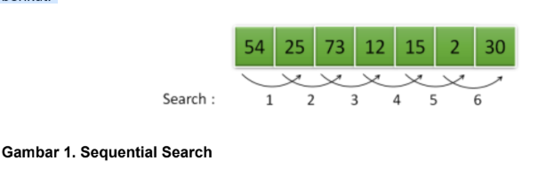

Terdapat dua konsep untuk sequential search berdasarkan kumpulan data yang akan dicari, yaitu

1. Unordered List Sequential Search
2. Ordered List Sequential Search

# Unordered List Sequential Search

Pada unordered list sequential search, data berada pada keadaan acak, tidak terurut, sehingga pencarian harus dilakukan mulai dari indeks awal sampai indeks terakhir dari data, atau pencarian berhenti ketika data sudah ditemukan

Berikut implementasi algoritma unordered list sequential search.

```python
def seqSearch(listData, data):

    ind = 0
    found = False

    while ind < len(listData) and not found:

        if listData[ind] == data:
            found = True
        else:
            ind = ind + 1

    return found
a=[12,5,9,8,1,10,26]
seqSearch(a,1)
```

```
True
```

# Ordered List Sequential Search

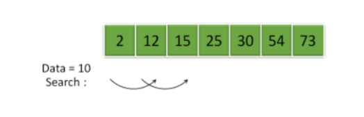

```python
def orderedSeqSearch(listData, data):

    ind = 0
    found = False
    stop = False
    position = []

    while ind < len(listData) and not found and not stop:

        if listData[ind] == data:
            found = True
            position.append(ind)

        else:
            if listData[ind] > data:
                stop = True
            else:
                ind = ind + 1

    if found:
        return ind
    else:
        return 'Data tidak ada'
a=[1,1,5,5,5,8,9,10,12,26]
ind=orderedSeqSearch(a,5)
print(ind)
```

```
2
```